# HW4

Dhanvin Lakshmisha

2025-02-20

Dhanvin Lakshmisha

dl37833

SDS 315

GitHub link - https://github.com/DhanvinL/SDS315-HW4

## Question 1

The null hypothesis is that the probability of security trades getting flagged from Iron Bank is 2.4%, which is the same rate as that of other traders.

The test statistic is the number of flagged trades, which is 70 in this case.

Here is a plot of the probability of the test statistic assuming the null hypothesis is true.

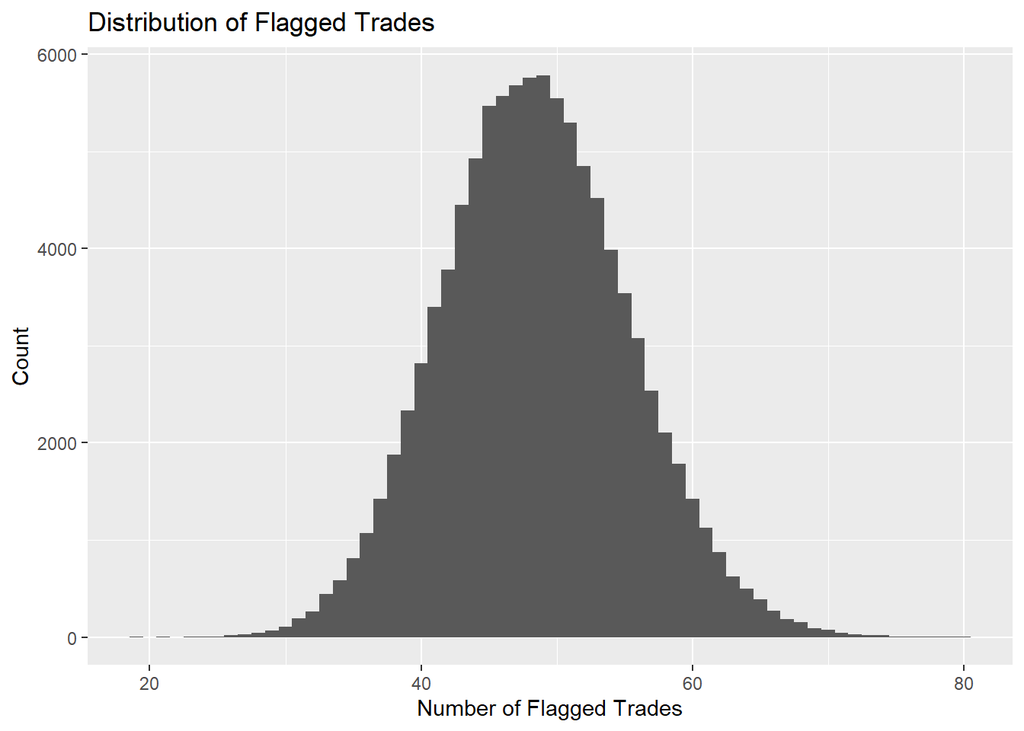

Based on our test statistic, we can find the p-value to see how our null hypothesis holds up.

```
## [1] 0.00207
```

The P-value which is less than .05 suggests that the Iron Bank’s trading activity is inconsistent with the expected rate of other traders.

## Question 2

The null hypothesis is that the probability of restaurants in the city getting a health code violation is 3%, which is the city average.

The test statistic is the number of violations in 50 inspections, which in this case is 8.

Here is the probability distribution for the statistic under the assumption the null hypothesis is true.

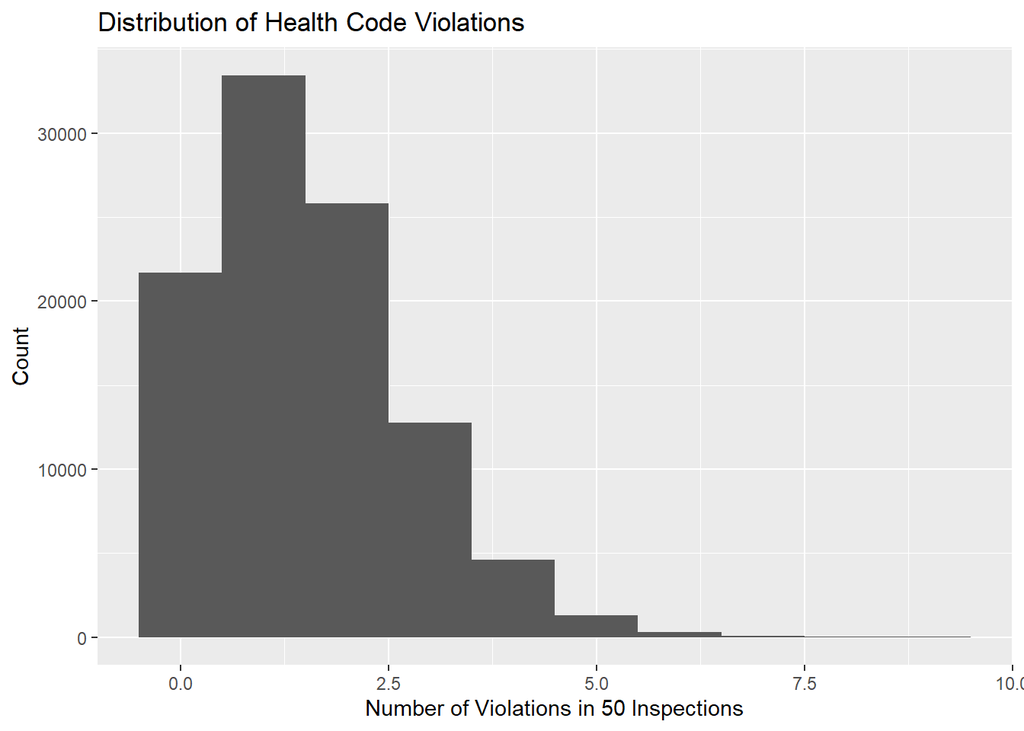

Based on this distribution, we can find the p-value.

```
## [1] 0.00017
```

The very low p-value tells us that the Gourmet Bites’ violation rate is significantly higher than the expected citywide violation rate.

## Question 3

The null hypothesis is that the distribution of jurors listed by the judge is not significantly different from the country’s population proportions.

The test statistic is the chi square test statistic. For this instance, the statistic is -

```
## [1] 12.42639
```

To understand this statistic we have to create a chi-square distribution of it. We are simulating the distribution through multinomial sampling.

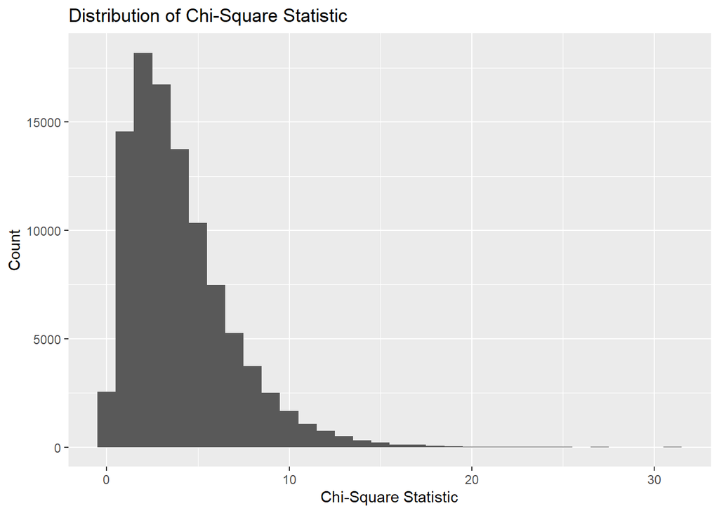

Based on this distribution we can get a p-value.

```
## [1] 0.01451
```

The p-value is 0.01451

The low p-value suggests that the distribution of jurors from this judge signiicantly differs from the expected distribution of judges.

## Question 4

### Part A

To see which sentence is watermarked by an LLM, we can create a null distribution or reference. This is based on the the chi-squared values of each sentence.

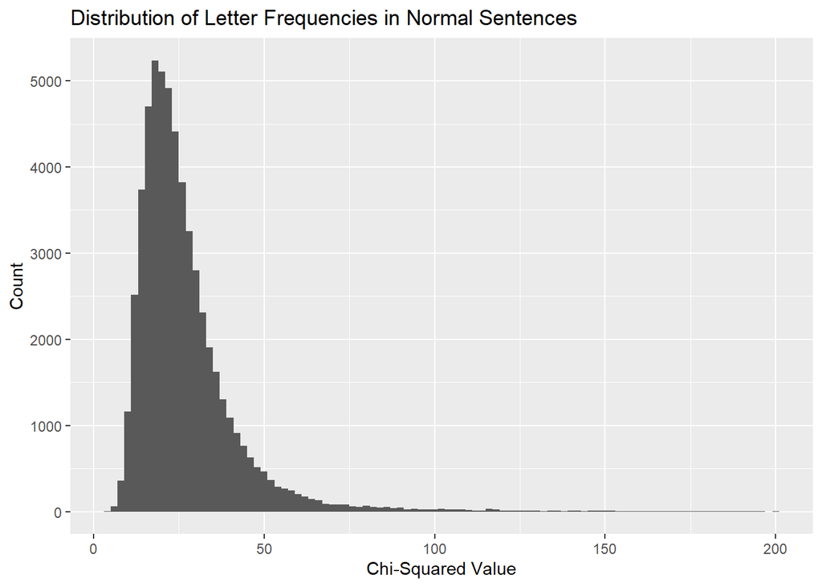

### Part B

Now, we can output a table of p-values for each sentence given.

| Sentence | P_Value |
| --- | --- |
| 1 | 0.513 |
| 2 | 0.926 |
| 3 | 0.076 |
| 4 | 0.489 |
| 5 | 0.484 |
| 6 | 0.009 |
| 7 | 0.328 |
| 8 | 0.988 |
| 9 | 0.084 |
| 10 | 0.059 |

Based on the distribution, we can assume that sentence 6 is the sentence produced by an LLM. This is due to it having the lowest p-value relative to other sentences. Also, it is the only p-value less than .05, which is the chosen significance level. If our null hypothesis was that each sentence follows the typical English letter frequency distribution (no watermark), we would reject the null hypothesis for sentence 6. Sentence 6’s letter frequencies are significantly different from that of English text.